# Sampling: Contamination

Xianbin Cheng

August 29, 2018

# Method

1. Load in libraries, visualization functions and check the session info.

```r
source(file = "Sampling_libraries.R")
source(file = "Sampling_visualization.R")
```

2. Define the input paramaters and create a simulation function.
- `n_sim` = the number of simulations
- `x_lim` = the limits of the horizontal axis
- `y_lim` = the limits of the vertical axis
- `x` = the horizontal coordinate of the contamination center, which follows a uniform distribution (`U(0,10)`)
- `y` = the vertical coordinate of the contamination center, which follows a uniform distribution(`U(0,10)`)

**Mode 1: Discrete Spread**

- `n_affected` = the number of affected plants near the contamination spot, which follows a Poisson distribution (`Pois(lambda = 5)`)
- `covar_mat` = covariance matrix of `x` and `y`, which defines the spread of contamination. Assume the spread follows a 2D normal distribution with var(X) = 0.25, var(Y) = 0.25 and cov(X, Y) = 0

**Mode 2: Continuous Spread**

- `spread_radius` = the radius of the contamination spread

```r
## The input parameters
n_sim = 3
x_lim = c(0, 10)
y_lim = c(0, 10)

### Mode 1
n_affected = rpois(n = 1, lambda = 5)
covar_mat = matrix(data = c(0.25, 0, 0, 0.25), nrow = 2, ncol = 2)

### Mode 2
spread_radius = 2.5
```

```r
## Some helper functions for creating unique identifiers for each observation.
naming_spread = function(df, spot, spread){
    a = rep(x = 1:spot, each = spread) %>% as.character()
    b = rep(x = 1:spread, times = spot) %>% as.character()
    c = paste(a, "-", b, sep = "")
    cbind(df, c)
  }

naming_spot = function(df, spot){
    a = 1:spot %>% as.character()
    b = rep(0, times = spot) %>% as.character()
    c = paste(a, "-", b, sep = "")
    cbind(df, c)
  }

## The simulation function for contamination spot and its spread
sim_contam = function(n_sim, x_lim, y_lim, covariance, n_affected, radius){

  ## Generate a matrix that contains contamination coordinates
  x = runif(n = n_sim, min = x_lim[1], max = x_lim[2])
  y = runif(n = n_sim, min = y_lim[1], max = y_lim[2])

  spot_coord = matrix(data = c(x, y), ncol = 2) %>% as.data.frame()

  # Each column of spread_coord contains 2*n_affected elements, the first n_affected elements are random numbers generated from mat_1[1,1] and the second n_affected elements are random numbers generated from mat_1[1,2]
  spread_coord = apply(X = spot_coord, MARGIN = 1, FUN = mvrnorm, n = n_affected, Sigma = covar_mat)

  # Split the spread_coord by columns, rearrange the vector of each list into an nx2 matrix, then combine these matrices by row.
  spread_coord_2 = split(x = spread_coord, f = col(spread_coord))
  spread_coord_3 = lapply(X = spread_coord_2, FUN = function(x){matrix(x, ncol = 2)})
  spread_coord_4 = do.call(what = rbind, args = spread_coord_3) %>% as.data.frame()

  # Give a unique identifier to each observation.
  spread_coord_5 = naming_spread(spread_coord_4, n_sim, n_affected)
  spot_coord_2 = naming_spot(spot_coord, n_sim)

  # Create a factor column.
  label = c(rep("spot", times = n_sim), rep("spread", times = n_sim * n_affected))

  # Create a spread radius column
  r = spread_radius

  # Combine the contamination spot coordinates and the spread coordinates, and then combine the factor column and the spread radius column.
  df_1 = rbind(spot_coord_2, spread_coord_5)
  colnames(df_1) = c("X", "Y", "ID")
  df_2 = cbind(df_1, label, r)

  # Remove points that are outside the perimeter.
  out = which(df_2[ ,1] < x_lim[1] | df_2[ , 1] > x_lim[2] | df_2[,2] < y_lim[1] | df_2[,2] > y_lim[2], arr.ind = TRUE)[1]
  if(is.na(out) == FALSE){
    df_3 = df_2[-out, ]
  } else {
    df_3 = df_2
  }

  # Reset the row names
  rownames(df_3) = NULL

  return(df_3)
}
```

3. Simulate the contamination center and its spread.

```r
# Run this if we want reproducibility
#set.seed(123)
```

```r
contam_xy = sim_contam(n_sim = n_sim, x_lim = x_lim, y_lim = y_lim, covariance = covar_mat, n_affected = n_affected, radius = spread_radius)
```

# Results

1. Visualization of contamination spots.

**Mode 1: Discrete Spread**

```r
plot_contam_dis = contam_draw(data = contam_xy, method = "discrete", xlim = x_lim, ylim = y_lim)
```

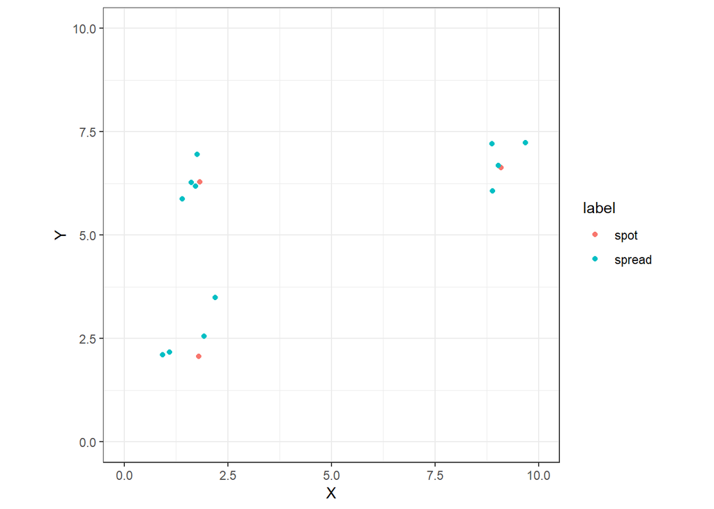

```r
plot_contam_dis
```

**Mode 2: Continuous Spread**

```r
plot_contam_cont = contam_draw(data = contam_xy, method = "continuous", xlim = x_lim, ylim = y_lim)
```

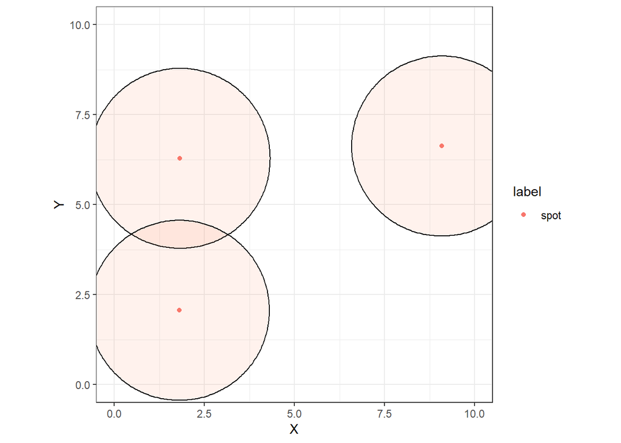

```r
plot_contam_cont
```

2. Visualization of the covariance matrix that describes the contamination spread.

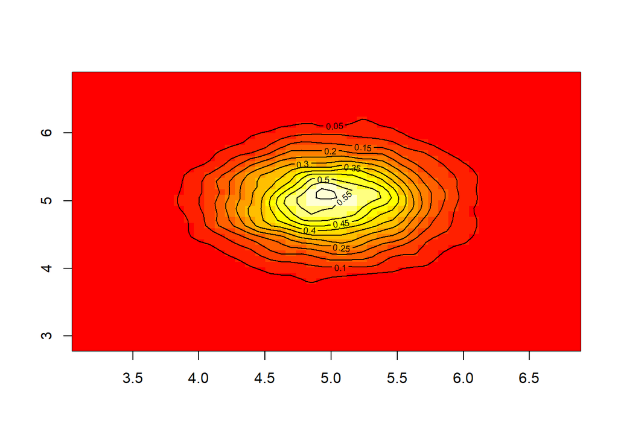

```r
### Visualize the covariance matrix
test = mvrnorm(n = 10000, mu = c(5,5), Sigma = covar_mat)
test = as.data.frame(test)
colnames(test) = c("X", "Y")

kernel_density = kde2d(x = test$X, y = test$Y, n = 50)
image(kernel_density)
contour(kernel_density, add = TRUE)
```